# T_vs_emissions

```python
import numpy as np
import matplotlib.pyplot as plt
import pandas as pd
```

Aim is to make Fig. SPM10 on p 38 of pdf IPPC Report

https://www.ipcc.ch/report/ar6/wg1/#FullReport

Download data from here

https://data.ceda.ac.uk/badc/ar6_wg1/data/spm/spm_10/v20210809

Use pandas to import data and make a basic plot.

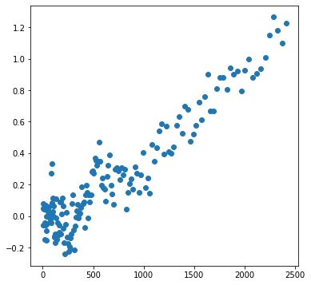

```python
data_file = "IPCC6_emissions_temp.csv"
df = pd.read_csv(data_file, sep=',', comment='#', header=None)

df = df.drop(df.columns[[0, 1]], axis=1)
df_x = df.iloc[[0]] # extract row 0
ipcc_emissions = df_x[:].values[0]

df_y = df.iloc[[1]] # extract row 1
ipcc_temp = df_y[:].values[0]

fig, ax = plt.subplots(1,1, figsize=(6, 6))

ax.scatter(ipcc_emissions,ipcc_temp)
```

Check against emissions data from other sources. Also as IPCC data file does not have dates we can check whether each point is one year. For example from https://ourworldindata.org/co2-emissions we can downloads emissions per year and then compare cumulative sum to IPCC data.

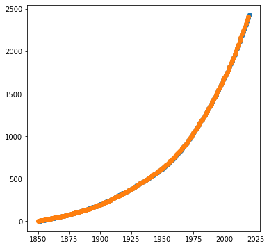

```python
data_file = "global-co2-fossil-plus-land-use.csv"
df2 = pd.read_csv(data_file, sep=',', comment='#', header=1,
                  usecols=[2,3],
                  names=['year','emissions'])

yr = pd.Series(df2['year']).values
em = pd.Series(df2['emissions']).values

fig, ax = plt.subplots(1,1, figsize=(6, 6))

ax.scatter(yr,np.cumsum(em)/1e9)

num = np.size(ipcc_temp)

ipcc_yr = 1850 + np.arange(0,num)

ax.scatter(ipcc_yr,ipcc_emissions)
```

IPCC and OWID data 'agree'. This is a small discrepancy on the 1% level.

Preferred colours for plots: Durham University palatte.

```python
dr=[190.0/255.0,30.0/255.0,45.0/255.0]
dy=[255.0/255.0,213.0/255.0,58.0/255.0]
dg=[175.0/255.0,169.0/255.0,97.0/255.0] # Durham green
db=[0,174.0/255.0,239.0/255.0]
dp=[104.0/255.0,36.0/255.0,109.0/255.0]
di=[0.0/255.0,42.0/255.0,65.0/255.0] # Durham ink
dpi=[203.0/255.0,168.0/255.0,177.0/255.0] #  Durham pink
ds=[218.0/255.0,205.0/255.0,162.0/255.0] # Durham stone
```

Now we make a linear fit to temperature vs. total CO2 so we can predict the future out to 2100.

```python
from scipy.optimize import leastsq, curve_fit

def fit1(x,A,B):
    return A+B*x

A,B = curve_fit(fit1,ipcc_emissions,ipcc_temp)[0] # exclude last two years take only 2250 points

xfit = np.arange(0,ipcc_emissions[num-1],ipcc_emissions[num-1]/num)
yfit = A + B * xfit
```

Use this linear fit model different emissions scenarios. Plot both emission per year and temperature vs. total CO2. To beautify we shall use Ed Hawkins warning colors. https://matplotlib.org/matplotblog/posts/warming-stripes/

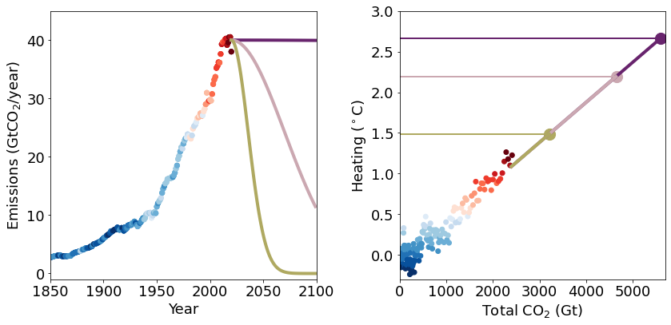

```python
from matplotlib.colors import ListedColormap

fig, [ax2, ax1] = plt.subplots(1,2, figsize=(12, 6))
plt.rcParams.update({'font.size': 18})

cmap = ListedColormap([
    '#08306b', '#08519c', '#2171b5', '#4292c6',
    '#6baed6', '#9ecae1', '#c6dbef', '#deebf7',
    '#fee0d2', '#fcbba1', '#fc9272', '#fb6a4a',
    '#ef3b2c', '#cb181d', '#a50f15', '#67000d',
])

ax1.scatter(ipcc_emissions,ipcc_temp, c = ipcc_temp, cmap = cmap)
ax1.set_xlabel('Total CO$_2$ (Gt)')
ax1.set_ylabel('Heating ($^\circ$C)')
ax1.set_xlim(0,5700)
ax1.set_ylim(-0.3,3.0)

ax2.scatter(yr,em/1e9, c = ipcc_temp, cmap = cmap)

future_yr = 2020 + np.arange(0,80) # goes to 2100!

ax2.set_xlim(1850,2100)
ax2.set_xticks([1850,1900,1950,2000,2050, 2100])
ax2.set_ylim(-1,45)
ax2.set_xlabel('Year')
ax2.set_ylabel('Emissions (GtCO$_2$/year)')

future_em = 40 * np.exp(-(future_yr - 2020)**2/5000000)
ax2.plot(future_yr,future_em, color = dp, linewidth = 4)
emissions_2100 = xfit[num-1] + np.sum(future_em)
x_future = np.arange(xfit[num-1],emissions_2100,10)
y_future = A + B * x_future
fnum = np.size(y_future)
ax1.plot(x_future,y_future, c = dp, linewidth = 4)

ax1.plot([0,emissions_2100],[y_future[fnum-1],y_future[fnum-1]], linewidth =2, color = dp)
ax1.scatter(emissions_2100,y_future[fnum-1], s = 200, color = [dp])

future_em = 40 * np.exp(-(future_yr - 2020)**2/5000)
ax2.plot(future_yr,future_em, color = dpi, linewidth = 4)
emissions_2100 = xfit[num-1] + np.sum(future_em)
x_future = np.arange(xfit[num-1],emissions_2100,10)
y_future = A + B * x_future
fnum = np.size(y_future)

ax1.plot(x_future,y_future, c = dpi, linewidth = 4)
ax1.scatter(emissions_2100,y_future[fnum-1], s = 200, color = [dpi])
ax1.plot([0,emissions_2100],[y_future[fnum-1],y_future[fnum-1]], linewidth =2, color = dpi)

future_em = 40 * np.exp(-(future_yr - 2020)**2/500)
ax2.plot(future_yr,future_em, color = dg, linewidth = 4)
ax2.scatter(yr,em/1e9, c = ipcc_temp, cmap = cmap)

emissions_2100 = xfit[num-1] + np.sum(future_em)
ax2.scatter(yr,em/1e9, c = ipcc_temp, cmap = cmap)

x_future = np.arange(xfit[num-1],emissions_2100,10)
y_future = A + B * x_future
ax1.plot(x_future,y_future, c = dg, linewidth = 4)

fnum = np.size(y_future)
ax1.scatter(emissions_2100,y_future[fnum-1], s = 200, color = [dg])
ax1.plot([0,emissions_2100],[y_future[fnum-1],y_future[fnum-1]], linewidth =2, color = dg)

fig.tight_layout()

fig.savefig('T_emission.png',bbox_inches='tight')
```

Note that as of October this year, the Energy Information Authority (EIA) of the US government were predicting the purple curve, emission to remain flat out to 2050. https://www.eia.gov/outlooks/ieo/